# Lecture 1

Shakeel Ahmed

2025-01-09

## Health Data Analysis in R

## In this Lecture we see how to analyze data in R (NHANES dataset)

- How to import data from stata
- View structure of variables in a data set
- Basic coding and handling missing and omitted data -Transforming variables _Weight Computation

## How to import data from stata

```r
library(haven)
DF <- read_dta("C:/Users/Admin/Downloads/Dr Shakeel/NHANES_2005-18_with_mortality.dta")
```

#See Data Structure

#See Data Structure for first 50 variables

```r
str(DF[, c(1:50)])
```

```
## tibble [70,190 × 50] (S3: tbl_df/tbl/data.frame)
##  $ seqn    : num [1:70190] 31127 31128 31129 31130 31131 ...
##   ..- attr(*, "label")= chr "Respondent sequence number"
##   ..- attr(*, "format.stata")= chr "%10.0g"
##  $ sddsrvyr: num [1:70190] 4 4 4 4 4 4 4 4 4 4 ...
##   ..- attr(*, "label")= chr "Data Release Number"
##   ..- attr(*, "format.stata")= chr "%10.0g"
##  $ ridstatr: num [1:70190] 2 2 2 2 2 2 2 2 2 1 ...
##   ..- attr(*, "label")= chr "Interview/Examination Status"
##   ..- attr(*, "format.stata")= chr "%10.0g"
##  $ ridexmon: num [1:70190] 2 1 2 2 2 2 2 2 2 NA ...
##   ..- attr(*, "label")= chr "Six month time period"
##   ..- attr(*, "format.stata")= chr "%10.0g"
##  $ riagendr: num [1:70190] 1 2 1 2 2 1 2 1 1 2 ...
##   ..- attr(*, "label")= chr "Gender"
##   ..- attr(*, "format.stata")= chr "%10.0g"
##  $ ridageyr: num [1:70190] 0 11 15 85 44 70 16 73 0 41 ...
##   ..- attr(*, "label")= chr "Age at Screening Adjudicated - Recode"
##   ..- attr(*, "format.stata")= chr "%10.0g"
##  $ ridagemn: num [1:70190] 11 132 189 NA 535 842 193 882 10 493 ...
##   ..- attr(*, "label")= chr "Age in Months - Recode"
##   ..- attr(*, "format.stata")= chr "%10.0g"
##  $ ridageex: num [1:70190] 12 132 190 NA 536 843 194 883 11 NA ...
##   ..- attr(*, "label")= chr "Exam Age in Months - Recode"
##   ..- attr(*, "format.stata")= chr "%10.0g"
##  $ ridreth1: num [1:70190] 3 4 4 3 4 3 4 3 5 4 ...
##   ..- attr(*, "label")= chr "Race/Ethnicity - Recode"
##   ..- attr(*, "format.stata")= chr "%10.0g"
##  $ dmqmilit: num [1:70190] NA NA NA 2 2 1 NA 1 NA 2 ...
##   ..- attr(*, "label")= chr "Veteran/Military Status"
##   ..- attr(*, "format.stata")= chr "%10.0g"
##  $ dmdborn : num [1:70190] 1 1 1 1 1 1 1 1 1 1 ...
##   ..- attr(*, "label")= chr "Country of Birth - Recode"
##   ..- attr(*, "format.stata")= chr "%10.0g"
##  $ dmdcitzn: num [1:70190] 1 1 1 1 1 1 1 1 1 1 ...
##   ..- attr(*, "label")= chr "Citizenship Status"
##   ..- attr(*, "format.stata")= chr "%10.0g"
##  $ dmdyrsus: num [1:70190] NA NA NA NA NA NA NA NA NA NA ...
##   ..- attr(*, "label")= chr "Length of time in US"
##   ..- attr(*, "format.stata")= chr "%10.0g"
```

[output cut: 96 more lines]

```
##  $ urxucr  : num [1:70190] NA 291 288 NA 202 162 275 140 NA NA ...
##   ..- attr(*, "label")= chr "Creatinine, urine (mg/dL)"
##   ..- attr(*, "format.stata")= chr "%10.0g"
##  $ urxcrs  : num [1:70190] NA 25724 25459 NA 17857 ...
##   ..- attr(*, "label")= chr "Creatinine, urine (umol/L)"
##   ..- attr(*, "format.stata")= chr "%10.0g"
##  $ alq101  : num [1:70190] NA NA NA NA 2 1 NA 1 NA NA ...
##   ..- attr(*, "label")= chr "Had at least 12 alcohol drinks/1 yr?"
##   ..- attr(*, "format.stata")= chr "%10.0g"
##  $ alq110  : num [1:70190] NA NA NA NA 1 NA NA NA NA NA ...
##   ..- attr(*, "label")= chr "Had at least 12 alcohol drinks/lifetime?"
##   ..- attr(*, "format.stata")= chr "%10.0g"
##  $ alq120q : num [1:70190] NA NA NA NA 0 4 NA 2 NA NA ...
##   ..- attr(*, "label")= chr "How often drink alcohol over past 12 mos"
##   ..- attr(*, "format.stata")= chr "%10.0g"
```

```r
#names(DF)
```

###Renaming variables

```r
names(DF)[names(DF) == "riagendr"] <- "sex" ##Gender
names(DF)[names(DF) == "ridageyr"] <- "age"##Age of respondent
names(DF)[names(DF) == "indfmin2"] <- "Income"
names(DF)[names(DF) == "ridreth3"] <- "Ethincity" ##Ethinicity
names(DF)[names(DF) == "dmdmartl"] <- "Marital"##marital status1,2,3,4,5 (ever married) vs 5(never married)
names(DF)[names(DF) == "dmdeduc2"] <- "Edu" ##Education <=2 >2
```

###Check distribution of different variables using freq command ###Install summarytools package for this purpose Replacing values or merging categies

```r
 library(summarytools)
freq(DF$Ethincity)
```

```
## Frequencies
## DF$Ethincity
## Label: Race/Hispanic origin w/ NH Asian
## Type: Numeric
##
##                Freq   % Valid   % Valid Cum.   % Total   % Total Cum.
## ----------- ------- --------- -------------- --------- --------------
##           1    6373     16.28          16.28      9.08           9.08
##           2    4164     10.63          26.91      5.93          15.01
##           3   12863     32.85          59.76     18.33          33.34
##           4    9194     23.48          83.24     13.10          46.44
##           6    4566     11.66          94.90      6.51          52.94
##           7    1996      5.10         100.00      2.84          55.79
##        <NA>   31034                              44.21         100.00
##       Total   70190    100.00         100.00    100.00         100.00
```

```r
freq(DF$Income)
```

```
## Frequencies
## DF$Income
## Label: Annual Family Income
## Type: Numeric
##
##                Freq   % Valid   % Valid Cum.   % Total   % Total Cum.
## ----------- ------- --------- -------------- --------- --------------
##           1    2147      3.66           3.66      3.06           3.06
##           2    2755      4.69           8.35      3.93           6.98
##           3    4178      7.12          15.47      5.95          12.94
##           4    4205      7.16          22.63      5.99          18.93
##           5    4711      8.03          30.66      6.71          25.64
##           6    6940     11.82          42.48      9.89          35.53
##           7    5434      9.26          51.74      7.74          43.27
##           8    4235      7.21          58.95      6.03          49.30
##           9    3231      5.50          64.46      4.60          53.91
##          10    2582      4.40          68.86      3.68          57.58
##          12    1647      2.81          71.66      2.35          59.93
##          13     790      1.35          73.01      1.13          61.06
##          14    4930      8.40          81.41      7.02          68.08
##          15    8696     14.81          96.22     12.39          80.47
##          77    1270      2.16          98.38      1.81          82.28
##          99     948      1.62         100.00      1.35          83.63
##        <NA>   11491                              16.37         100.00
##       Total   70190    100.00         100.00    100.00         100.00
```

```r
summary(DF$age)
```

```
##    Min. 1st Qu.  Median    Mean 3rd Qu.    Max.
##    0.00   10.00   26.00   31.78   53.00   85.00
```

```r
freq(DF$sex)
```

```
## Frequencies
## DF$sex
## Label: Gender
## Type: Numeric
##
##                Freq   % Valid   % Valid Cum.   % Total   % Total Cum.
## ----------- ------- --------- -------------- --------- --------------
##           1   34709     49.45          49.45     49.45          49.45
##           2   35481     50.55         100.00     50.55         100.00
##        <NA>       0                               0.00         100.00
##       Total   70190    100.00         100.00    100.00         100.00
```

```r
freq(DF$Ethincity)
```

```
## Frequencies
## DF$Ethincity
## Label: Race/Hispanic origin w/ NH Asian
## Type: Numeric
##
##                Freq   % Valid   % Valid Cum.   % Total   % Total Cum.
## ----------- ------- --------- -------------- --------- --------------
##           1    6373     16.28          16.28      9.08           9.08
##           2    4164     10.63          26.91      5.93          15.01
##           3   12863     32.85          59.76     18.33          33.34
##           4    9194     23.48          83.24     13.10          46.44
##           6    4566     11.66          94.90      6.51          52.94
##           7    1996      5.10         100.00      2.84          55.79
##        <NA>   31034                              44.21         100.00
##       Total   70190    100.00         100.00    100.00         100.00
```

```r
freq(DF$Marital)
```

```
## Frequencies
## DF$Marital
## Label: Marital Status
## Type: Numeric
##
##                Freq    % Valid   % Valid Cum.    % Total   % Total Cum.
## ----------- ------- ---------- -------------- ---------- --------------
##           1   20284    48.9148        48.9148    28.8987        28.8987
##           2    3371     8.1292        57.0440     4.8027        33.7014
##           3    4292    10.3501        67.3941     6.1148        39.8162
##           4    1349     3.2531        70.6472     1.9219        41.7381
##           5    8857    21.3586        92.0059    12.6186        54.3567
##           6    3279     7.9073        99.9132     4.6716        59.0284
##          77      31     0.0748        99.9879     0.0442        59.0725
##          99       5     0.0121       100.0000     0.0071        59.0796
##        <NA>   28722                              40.9204       100.0000
##       Total   70190   100.0000       100.0000   100.0000       100.0000
```

```r
freq(DF$Edu)
```

```
## Frequencies
## DF$Edu
## Label: Education Level - Adults 20+
## Type: Numeric
##
##                Freq   % Valid   % Valid Cum.   % Total   % Total Cum.
## ----------- ------- --------- -------------- --------- --------------
##           1    4382    11.024         11.024     6.243          6.243
##           2    5708    14.360         25.384     8.132         14.375
##           3    9102    22.899         48.283    12.968         27.343
##           4   11561    29.085         77.368    16.471         43.814
##           5    8935    22.479         99.847    12.730         56.544
##           7      19     0.048         99.894     0.027         56.571
##           9      42     0.106        100.000     0.060         56.631
##        <NA>   30441                             43.369        100.000
##       Total   70190   100.000        100.000   100.000        100.000
```

##Summarizing Continous variables

```r
summary(DF$Income)
```

```
##    Min. 1st Qu.  Median    Mean 3rd Qu.    Max.    NA's
##    1.00    5.00    7.00   11.08   14.00   99.00   11491
```

```r
summary(DF$age)
```

```
##    Min. 1st Qu.  Median    Mean 3rd Qu.    Max.
##    0.00   10.00   26.00   31.78   53.00   85.00
```

##Replacing missing values by 99

```r
DF[is.na(DF)] <- 99
```

##Recoding Variables

```r
DF$Edu_c<-ifelse(DF$Edu<=3,0,ifelse(DF$Edu>3&DF$Edu<99,1,99))
DF$Income_c<-ifelse(DF$Income<=8,0,ifelse(DF$Income>8&DF$Income<77,1,99))
```

##Replacing Specific Value by other values( Example: merging two categories in Ethnicity)

```r
DF$Ethincity[DF$Ethincity == "7"] <-"6"
freq(DF$Ethincity)
```

```
## Frequencies
## DF$Ethincity
## Label: Race/Hispanic origin w/ NH Asian
## Type: Character
##
##                Freq   % Valid   % Valid Cum.   % Total   % Total Cum.
## ----------- ------- --------- -------------- --------- --------------
##           1    6373      9.08           9.08      9.08           9.08
##           2    4164      5.93          15.01      5.93          15.01
##           3   12863     18.33          33.34     18.33          33.34
##           4    9194     13.10          46.44     13.10          46.44
##           6    6562      9.35          55.79      9.35          55.79
##          99   31034     44.21         100.00     44.21         100.00
##        <NA>       0                               0.00         100.00
##       Total   70190    100.00         100.00    100.00         100.00
```

##Labeling (Values)

```r
DF$Edu_c <- factor(DF$Edu_c,
levels = c(0,1,99),
labels = c("Low Education", "High Education", "Do not know"))
DF$Income_c <- factor(DF$Income_c,
levels = c(0,1,99),
labels = c("Low Income", "High Income", "Do not know"))
freq(DF$Edu_c)
```

```
## Frequencies
## DF$Edu_c
## Type: Factor
##
##                         Freq   % Valid   % Valid Cum.   % Total   % Total Cum.
## -------------------- ------- --------- -------------- --------- --------------
##        Low Education   19192     27.34          27.34     27.34          27.34
##       High Education   20557     29.29          56.63     29.29          56.63
##          Do not know   30441     43.37         100.00     43.37         100.00
##                 <NA>       0                               0.00         100.00
##                Total   70190    100.00         100.00    100.00         100.00
```

```r
freq(DF$Income_c)
```

```
## Frequencies
## DF$Income_c
## Type: Factor
##
##                      Freq   % Valid   % Valid Cum.   % Total   % Total Cum.
## ----------------- ------- --------- -------------- --------- --------------
##        Low Income   34605     49.30          49.30     49.30          49.30
##       High Income   21876     31.17          80.47     31.17          80.47
##       Do not know   13709     19.53         100.00     19.53         100.00
##              <NA>       0                               0.00         100.00
##             Total   70190    100.00         100.00    100.00         100.00
```

##Tabulation in R ###2-Way Frequency Table

```r
mytable <- table(DF$Edu_c,DF$Income_c) # A will be rows, B will be columns
mytable # print table
```

```
##
##                  Low Income High Income Do not know
##   Low Education       11680        3738        3774
##   High Education       8335        8914        3308
##   Do not know         14590        9224        6627
```

##Percentages by row or by column

```r
prop.table(mytable) # cell percentages
```

```
##
##                  Low Income High Income Do not know
##   Low Education  0.16640547  0.05325545  0.05376834
##   High Education 0.11874911  0.12699815  0.04712922
##   Do not know    0.20786437  0.13141473  0.09441516
```

```r
prop.table(mytable, 1) # row percentages
```

```
##
##                  Low Income High Income Do not know
##   Low Education   0.6085869   0.1947687   0.1966444
##   High Education  0.4054580   0.4336236   0.1609184
##   Do not know     0.4792878   0.3030124   0.2176998
```

```r
prop.table(mytable, 2) # column percentages
```

```
##
##                  Low Income High Income Do not know
##   Low Education   0.3375235   0.1708722   0.2752936
##   High Education  0.2408611   0.4074785   0.2413013
##   Do not know     0.4216154   0.4216493   0.4834051
```

##Apply Chi square test

```r
summary(mytable) # chi-square test of indepedence
```

```
## Number of cases in table: 70190
## Number of factors: 2
## Test for independence of all factors:
##  Chisq = 2883.8, df = 4, p-value = 0
```

```r
chisq.test(DF$Income_c, DF$Edu_c)
```

```
##
##  Pearson's Chi-squared test
##
## data:  DF$Income_c and DF$Edu_c
## X-squared = 2883.8, df = 4, p-value < 2.2e-16
```

##3-Way table # 3-Way Frequency Table

```r
attach(DF)
mytable3 <- table(Edu_c,Income_c, Ethincity)
ftable(mytable3)
```

```
##                            Ethincity    1    2    3    4    6   99
## Edu_c          Income_c
## Low Education  Low Income            1454  906 2278 1680  686 4676
##                High Income            476  266  727  481  329 1459
##                Do not know            216  159  131  184  119 2965
## High Education Low Income             423  504 2426 1399  908 2675
##                High Income            401  452 2571 1195 1534 2761
##                Do not know             67   84  178  189  194 2596
## Do not know    Low Income            2210 1085 2140 2763 1138 5254
##                High Income            881  537 2313 1086 1464 2943
##                Do not know            245  171   99  217  190 5705
```

```r
summary(mytable3) # chi-square test of indepedence
```

```
## Number of cases in table: 70190
## Number of factors: 3
## Test for independence of all factors:
##  Chisq = 17553, df = 44, p-value = 0
```

# 4-Way Frequency Table

```r
attach(DF)
mytable4 <- table(Edu_c,Income_c, Marital, Ethincity)
ftable(mytable4)
```

```
##                                    Ethincity    1    2    3    4    6   99
## Edu_c          Income_c    Marital
## Low Education  Low Income  1                  753  354  934  433  408 2104
##                            2                  101   79  370  208   56  588
##                            3                  106  108  389  218   54  537
##                            4                  103   77   64  114   20  221
##                            5                  178  151  303  538  101  764
##                            6                  212  137  216  169   47  462
##                            77                   1    0    0    0    0    0
##                            99                   0    0    2    0    0    0
##                High Income 1                  326  167  485  227  228  916
##                            2                   25   18   51   39   27  113
##                            3                   13   17   44   43   13  102
##                            4                   21    4    7   15   10   36
##                            5                   47   31   87  125   35  206
```

[output cut: 59 more lines]

```r
summary(mytable4) # chi-square test of indepedence
```

```
## Number of cases in table: 70190
## Number of factors: 4
## Test for independence of all factors:
##  Chisq = 111196, df = 415, p-value = 0
##  Chi-squared approximation may be incorrect
```

###Two-way Table for one variable with multiple other variables variables

```r
table5<-table(Edu_c, sex)
table6<-table(Marital, sex)
table7<-table(Ethincity, sex)
table8<-table(Income_c, sex)
list(table5, table6, table7, table8)
```

```
## [[1]]
##                 sex
## Edu_c                1     2
##   Low Education   9701  9491
##   High Education  9549 11008
##   Do not know    15459 14982
##
## [[2]]
##        sex
## Marital     1     2
##      1  10723  9561
##      2    850  2521
##      3   1783  2509
##      4    533   816
##      5   4513  4344
##      6   1679  1600
##      77    12    19
##      99 14616 14111
##
## [[3]]
##          sex
## Ethincity     1     2
##        1   3067  3306
##        2   1964  2200
##        3   6492  6371
##        4   4519  4675
##        6   3266  3296
##        99 15401 15633
##
## [[4]]
##              sex
## Income_c          1     2
##   Low Income  16847 17758
##   High Income 11115 10761
##   Do not know  6747  6962
```

###Descriptive statistics for survey weighted data ##Required Packages

```r
#install.packages("survey")
#install.packages("jtools")
#install.packages("remotes")
#remotes::install_github("carlganz/svrepmisc")
```

```r
library("haven")
library("survey")
library("jtools")
library("remotes")
library("svrepmisc")
```

##Obtaining weight

```r
#DF$wtmec2yr##Weight two year
```

## The svydesign function tells R about the design elements in the survey.

```r
SDes <- svydesign(id=~sdmvpsu, weights=~wtmec2yr,strata=~sdmvstra, nest=TRUE, survey.lonely.psu = "adjust", data=DF)
SDes
```

```
## Stratified 1 - level Cluster Sampling design (with replacement)
## With (214) clusters.
## svydesign(id = ~sdmvpsu, weights = ~wtmec2yr, strata = ~sdmvstra,
##     nest = TRUE, survey.lonely.psu = "adjust", data = DF)
```

##Summary of design information

```r
summary(SDes)
```

```
## Stratified 1 - level Cluster Sampling design (with replacement)
## With (214) clusters.
## svydesign(id = ~sdmvpsu, weights = ~wtmec2yr, strata = ~sdmvstra,
##     nest = TRUE, survey.lonely.psu = "adjust", data = DF)
## Probabilities:
##      Min.   1st Qu.    Median      Mean   3rd Qu.      Max.
## 2.382e-06 2.749e-05 5.062e-05       Inf 8.936e-05       Inf
## Stratum Sizes:
##             44  45  46  47  48  49  50  51  52  53  54  55  56  57  58  59  60
## obs        760 653 768 631 628 936 651 629 696 617 689 668 772 694 556 711 740
## design.PSU   2   2   2   2   2   2   2   2   2   2   2   2   2   2   2   2   2
## actual.PSU   2   2   2   2   2   2   2   2   2   2   2   2   2   2   2   2   2
##             61  62  63  64  65  66  67  68  69  70  71  72  73  74  75  76  77
## obs        852 788 694 689 731 716 797 714 530 541 560 561 267 258 803 785 823
## design.PSU   2   2   2   2   2   2   2   2   2   2   2   2   2   2   2   2   2
```

[output cut: 214 more lines]

##Why survey weighting is important ##see https://survalyzer.com/weighting-survey-data/ ##Descriptive statistics with continuous variables ##calculating the mean of a continuous variable.

###For more than one variables

```r
svymean(~age+Income, SDes, na=TRUE)
```

```
##          mean     SE
## age    37.238 0.2222
## Income 24.422 0.6650
```

```r
svysd(~age+Income, SDes)
```

```
##        std. dev.
## age       22.396
## Income    33.588
```

##Mean with 95% CI For more than one variables

```r
confint(svymean(~age+Income, SDes))
```

```
##           2.5 %   97.5 %
## age    36.80229 37.67323
## Income 23.11865 25.72536
```

```r
cbind(svymean(~age+Income, SDes, na=TRUE), confint(svymean(~age+Income, SDes)))
```

```
##                    2.5 %   97.5 %
## age    37.23776 36.80229 37.67323
## Income 24.42201 23.11865 25.72536
```

####The coefficient of variation. ##The coefficient of variation is the ratio of the standard error to the mean, multiplied by 100%. ##It is an indication of the variability relative to the mean in the population ##It is not affected by the unit of measurement of the variable.

```r
cv(svymean(~age+Income,design = SDes, na = TRUE))
```

```
##         age      Income
## 0.005966634 0.027229097
```

###The Deff is a ratio of two variances. ##In the numerator: the variance estimate from the current sample (including all of its design elements), ###and in the denominator: a hypothetical sample of the same size drawn as an SRS. ###the Deff tells you how efficient your sample is compared to an SRS of equal size.

```r
svymean(~age, SDes, na = TRUE, deff = TRUE)
```

```
##         mean       SE   DEff
## age 37.23776  0.22218 6.6302
```

###Quantiles are a useful descriptive statistic for continuous variables, ##particularly variables that are not normally distributed.

```r
svyquantile(~age, design = SDes, na = TRUE, c(.25,.5,.75),ci=TRUE)
```

```
## $age
##      quantile ci.2.5 ci.97.5        se
## 0.25       18     18      19 0.2522746
## 0.5        37     37      38 0.2522746
## 0.75       55     55      56 0.2522746
##
## attr(,"hasci")
## [1] TRUE
## attr(,"class")
## [1] "newsvyquantile"
```

###Estimation of Weighted Proportion for a binary variable

```r
#options("scipen"=100000, "digits"=3)##Avoid Scientific notations
data.frame(svytable(~sex, design=SDes), round(prop.table(svytable(~sex, design=SDes)),2))
```

```
##   sex       Freq sex.1 Freq.1
## 1   1 1049235666     1   0.49
## 2   2 1096579703     2   0.51
```

```r
data.frame(svytable(~Income_c, design=SDes), round(prop.table(svytable(~Income_c, design=SDes)),2))
```

```
##      Income_c      Freq  Income_c.1 Freq.1
## 1  Low Income 892603100  Low Income   0.42
## 2 High Income 883198655 High Income   0.41
## 3 Do not know 370013614 Do not know   0.17
```

```r
rbind(svytable(~Edu_c, design=SDes), round(prop.table(svytable(~Edu_c, design=SDes)),2))
```

```
##      Low Education High Education Do not know
## [1,]  622264679.86   948365696.66 5.75185e+08
## [2,]          0.29           0.44 2.70000e-01
```

###Cross Tabulation for two variables

```r
prop.table(svytable(~sex+Edu_c, SDes), 1)##Survey Table for row %
```

```
##    Edu_c
## sex Low Education High Education Do not know
##   1     0.2986381      0.4214104   0.2799516
##   2     0.2817150      0.4616235   0.2566615
```

```r
prop.table(svytable(~sex+Edu_c, SDes), 2)##Survey Table for Column %
```

```
##    Edu_c
## sex Low Education High Education Do not know
##   1     0.5035505      0.4662324   0.5106795
##   2     0.4964495      0.5337676   0.4893205
```

```r
svychisq(~sex+Edu_c, SDes, statistic="Chisq")## For other options see documentation of svychisq
```

```
##
##  Pearson's X^2: Rao & Scott adjustment
##
## data:  svychisq(~sex + Edu_c, SDes, statistic = "Chisq")
## X-squared = 116.99, df = 2, p-value = 1.447e-15
```

```r
svychisq(~sex+Edu_c, SDes, statistic="adjWald")#
```

```
##
##  Design-based Wald test of association
##
## data:  svychisq(~sex + Edu_c, SDes, statistic = "adjWald")
## F = 29.875, ndf = 2, ddf = 108, p-value = 4.712e-11
```

```r
svyby(~age+Income, ~Ethincity, SDes, svymean)
```

```
##    Ethincity      age   Income    se.age se.Income
## 1          1 28.63754 14.07245 0.4179722 0.7956257
## 2          2 32.38318 16.35630 0.5797505 1.0728527
## 3          3 41.06057 12.42458 0.4309419 0.2818181
## 4          4 34.59613 12.58465 0.4176509 0.4396918
## 6          6 34.71974 14.90263 0.5115625 0.5908135
## 99        99 36.46927 40.35021 0.3467237 1.3725001
```

##Median age by ethnicity

```r
svyby(~age, ~Ethincity, SDes, svyquantile, quantiles=0.5)
```

```
##    Ethincity age    se.age
## 1          1  26 0.7493565
## 2          2  31 0.7503859
## 3          3  42 0.7503859
## 4          4  33 0.7498883
## 6          6  33 1.0005145
## 99        99  36 0.4970820
```

####Two way stratification

```r
svyby(~age+Income, ~sex+Ethincity, SDes, svymean, keep.var=TRUE)
```

```
##      sex Ethincity      age   Income    se.age se.Income
## 1.1    1         1 28.69059 14.22369 0.4746253 0.8521006
## 2.1    2         1 28.58284 13.91650 0.5089908 0.8132773
## 1.2    1         2 30.69446 16.83035 0.6619855 1.1169569
## 2.2    2         2 34.01657 15.89778 0.6639319 1.1605253
## 1.3    1         3 40.00456 12.70722 0.4702510 0.3558899
## 2.3    2         3 42.07403 12.15333 0.4602461 0.2892896
## 1.4    1         4 33.20933 13.36022 0.4503301 0.5015587
## 2.4    2         4 35.79344 11.91506 0.4713178 0.4382810
## 1.6    1         6 34.42156 14.94718 0.6007037 0.6118343
## 2.6    2         6 35.00487 14.86003 0.6933754 0.7061541
## 1.99   1        99 35.46795 40.38605 0.3762286 1.4361370
## 2.99   2        99 37.43003 40.31581 0.3615831 1.3417063
```

##Constructing attractive tables of summary statistics using the output from these functions. ##We use the survey design object created SDes in last code. ##Estimation of proportions in the cells of a contingency table

```r
cell_prop <- svymean(~interaction(sex, Ethincity), design = SDes)
cell_prop
```

```
##                                     mean     SE
## interaction(sex, Ethincity)1.1  0.031317 0.0032
## interaction(sex, Ethincity)2.1  0.030371 0.0030
## interaction(sex, Ethincity)1.2  0.019696 0.0016
## interaction(sex, Ethincity)2.2  0.020364 0.0017
## interaction(sex, Ethincity)1.3  0.175268 0.0073
## interaction(sex, Ethincity)2.3  0.182626 0.0079
## interaction(sex, Ethincity)1.4  0.032719 0.0025
## interaction(sex, Ethincity)2.4  0.037897 0.0031
## interaction(sex, Ethincity)1.6  0.026717 0.0016
## interaction(sex, Ethincity)2.6  0.027940 0.0017
## interaction(sex, Ethincity)1.99 0.203251 0.0050
## interaction(sex, Ethincity)2.99 0.211834 0.0052
```

##The ftable function reshapes output like this into a flattened table.

```r
cross_tab<- ftable(cell_prop)
cross_tab<- ftable(cell_prop,rownames = list(sex = c("Male", "Female"
             ), Ethincity = c("Hisp", "Nonhisp", "Non white", "Others","")))
round(cross_tab,digits=3)
```

[output not shown]

```r
cross_tab
```

[output not shown]

###For continous variables

```r
Table_mean<-svyby(~age + Income, ~sex+Ethincity, SDes, svymean, keep.var=TRUE)
Table_mean
```

```
##      sex Ethincity      age   Income    se.age se.Income
## 1.1    1         1 28.69059 14.22369 0.4746253 0.8521006
## 2.1    2         1 28.58284 13.91650 0.5089908 0.8132773
## 1.2    1         2 30.69446 16.83035 0.6619855 1.1169569
## 2.2    2         2 34.01657 15.89778 0.6639319 1.1605253
## 1.3    1         3 40.00456 12.70722 0.4702510 0.3558899
## 2.3    2         3 42.07403 12.15333 0.4602461 0.2892896
## 1.4    1         4 33.20933 13.36022 0.4503301 0.5015587
## 2.4    2         4 35.79344 11.91506 0.4713178 0.4382810
## 1.6    1         6 34.42156 14.94718 0.6007037 0.6118343
## 2.6    2         6 35.00487 14.86003 0.6933754 0.7061541
## 1.99   1        99 35.46795 40.38605 0.3762286 1.4361370
## 2.99   2        99 37.43003 40.31581 0.3615831 1.3417063
```

##Graphing continuous variable ##Histogram for weighted data

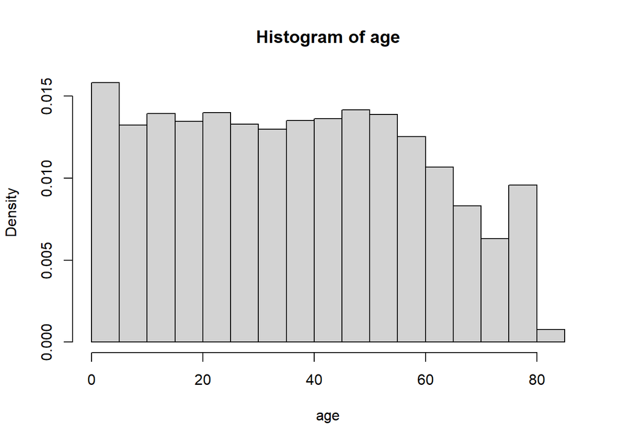

```r
svyhist(~age, SDes)
```

##Histogram with frequencies

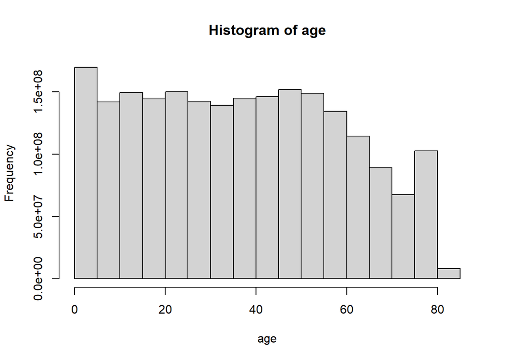

```r
svyhist(~age, SDes, probability = FALSE)
```

###Survey Weighted Box Plot

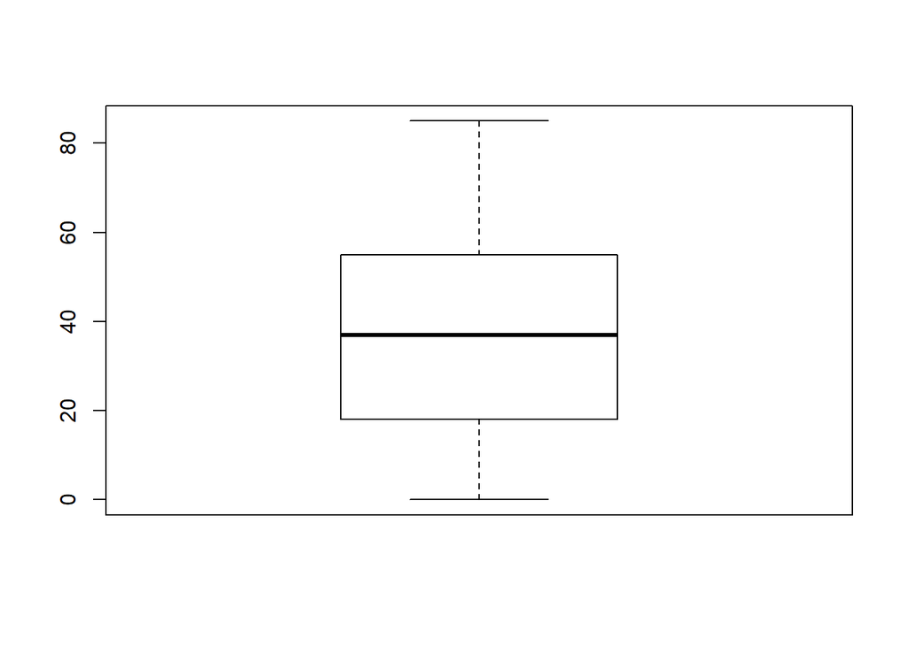

```r
svyboxplot(~age~1, SDes, all.outliers=TRUE)
```

##boxplot by a grouping variable. The grouping variable must be a factor.

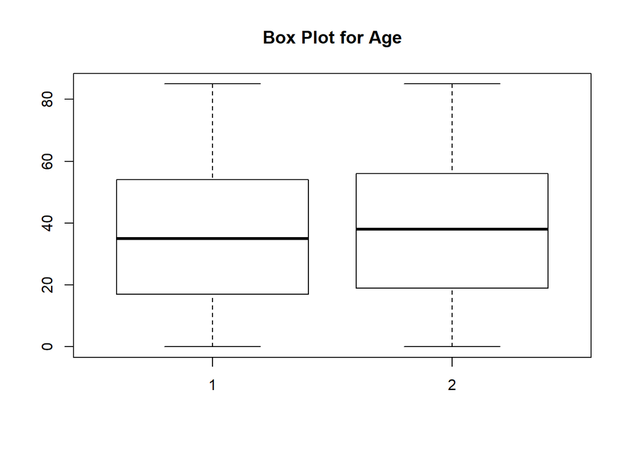

```r
svyboxplot(~age~factor(sex), SDes, all.outliers=TRUE, main="Box Plot for Age")
```

##Survey Weighted Bar Chart for subpopulation analysis

[figure not shown]

```r
barplt<-svyby(~Income_c+Edu_c, ~sex, SDes, na = TRUE, svymean)
barplot(barplt,beside=TRUE,legend=TRUE, main="Box Plot for Age")
```

### Scatterplot with the sampling weights corresponding to the circle size.

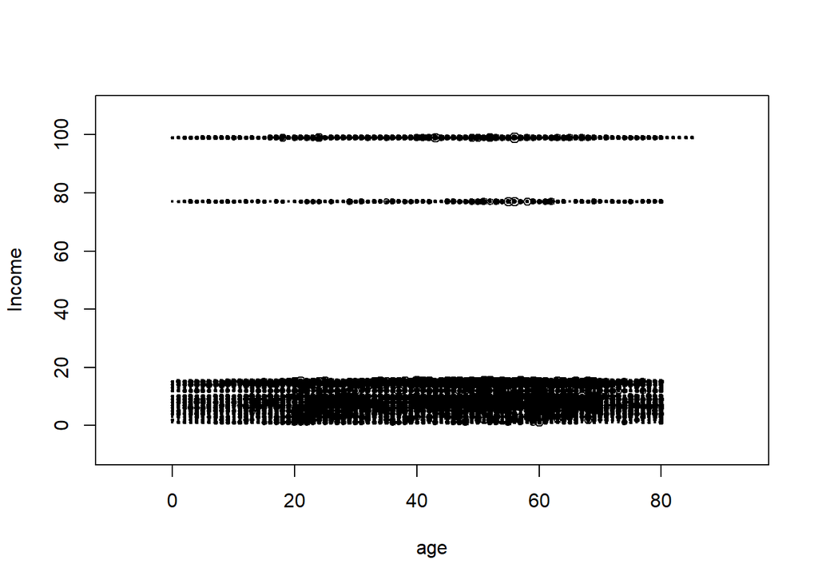

```r
svyplot(~age+Income, SDes, style="bubble")
```

## smoothed plots.

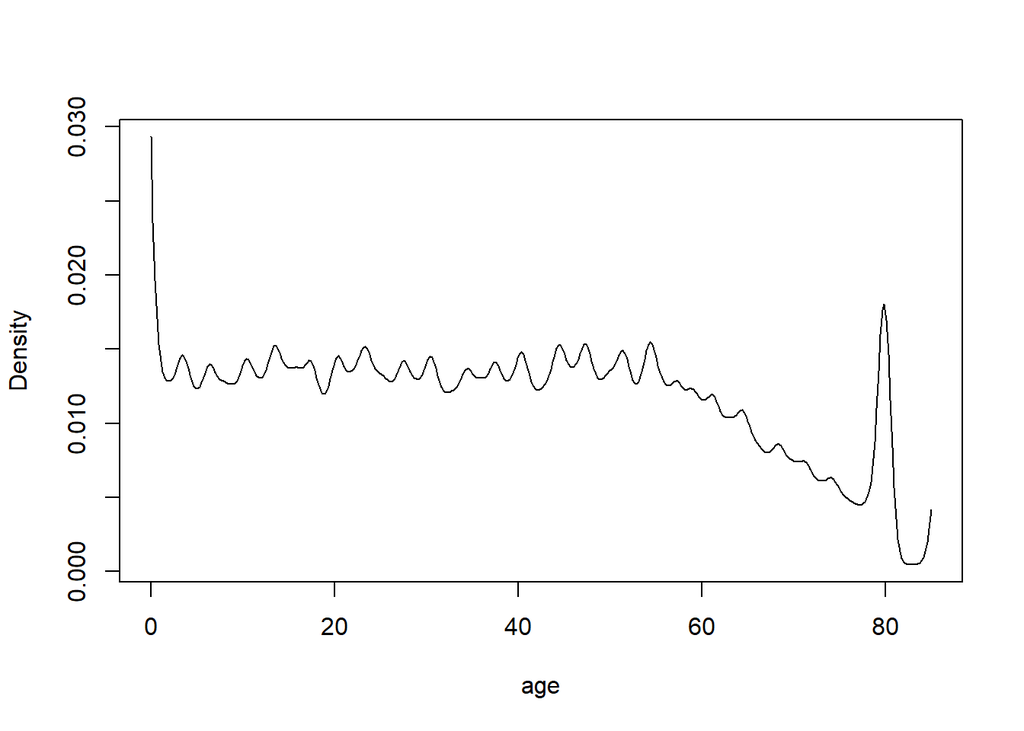

```r
smth<-svysmooth(~age, design=SDes)
plot(smth)
```

##Density plot with bandwith

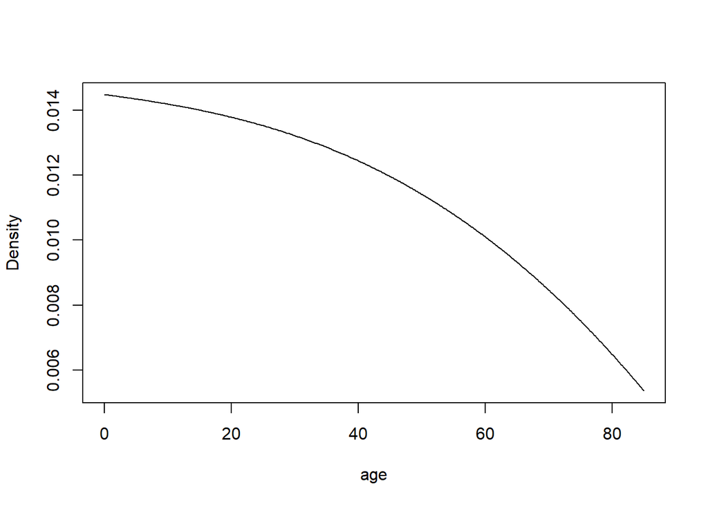

```r
dens<-svysmooth(~age, design=SDes,bandwidth=30)
plot(dens)
```

##Density plot smooth

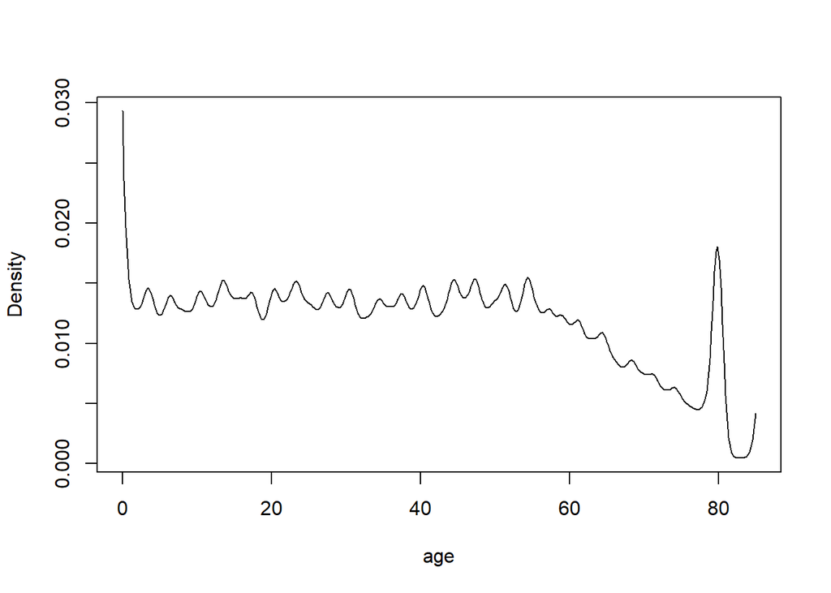

```r
dens1<-svysmooth(~age, design=SDes)

plot(dens1)
```

##Testing of Hypothesis for weighted data ##One sample t-test

```r
svyttest(age~0, SDes, na = TRUE)
```

```
##
##  Design-based one-sample t-test
##
## data:  age ~ 0
## t = 167.6, df = 108, p-value < 2.2e-16
## alternative hypothesis: true mean is not equal to 0
## 95 percent confidence interval:
##  36.79735 37.67817
## sample estimates:
##     mean
## 37.23776
```

##Independent samples t-test

```r
tt=svyttest(age~sex, SDes)
```

## Confidence Interval for difference of means

```r
confint(tt, level=0.95)
```

```
##       2.5 %   97.5 %
## sex 1.56598 2.262959
## attr(,"conf.level")
## [1] 0.95
```

#Alternative You can using a simple linear regression using svyglm

```r
summary(svyglm(age~sex, design=SDes))
```

```
##
## Call:
## svyglm(formula = age ~ sex, design = SDes)
##
## Survey design:
## svydesign(id = ~sdmvpsu, weights = ~wtmec2yr, strata = ~sdmvstra,
##     nest = TRUE, survey.lonely.psu = "adjust", data = DF)
##
## Coefficients:
##             Estimate Std. Error t value Pr(>|t|)
## (Intercept)  34.3449     0.3433  100.03   <2e-16 ***
## sex           1.9145     0.1758   10.89   <2e-16 ***
## ---
## Signif. codes:  0 '***' 0.001 '**' 0.01 '*' 0.05 '.' 0.1 ' ' 1
##
## (Dispersion parameter for gaussian family taken to be 500.6617)
##
## Number of Fisher Scoring iterations: 2
```

```r
summary(svyglm(age~sex, design=SDes))
```

```
##
## Call:
## svyglm(formula = age ~ sex, design = SDes)
##
## Survey design:
## svydesign(id = ~sdmvpsu, weights = ~wtmec2yr, strata = ~sdmvstra,
##     nest = TRUE, survey.lonely.psu = "adjust", data = DF)
##
## Coefficients:
##             Estimate Std. Error t value Pr(>|t|)
## (Intercept)  34.3449     0.3433  100.03   <2e-16 ***
## sex           1.9145     0.1758   10.89   <2e-16 ***
## ---
## Signif. codes:  0 '***' 0.001 '**' 0.01 '*' 0.05 '.' 0.1 ' ' 1
##
## (Dispersion parameter for gaussian family taken to be 500.6617)
##
## Number of Fisher Scoring iterations: 2
```

##Paired samples t-test

```r
svyttest(I(pad660-pad675)~0, SDes, na = TRUE)
```

```
##
##  Design-based one-sample t-test
##
## data:  I(pad660 - pad675) ~ 0
## t = 9.8036, df = 108, p-value < 2.2e-16
## alternative hypothesis: true mean is not equal to 0
## 95 percent confidence interval:
##  4.658739 7.020061
## sample estimates:
##   mean
## 5.8394
```

##Linear Regression for Survey Weighted Data

```r
Fit1<-svyglm(pad630~sex+Edu_c, design=SDes, na.action = na.omit)
summary(Fit1)
```

```
##
## Call:
## svyglm(formula = pad630 ~ sex + Edu_c, design = SDes, na.action = na.omit)
##
## Survey design:
## svydesign(id = ~sdmvpsu, weights = ~wtmec2yr, strata = ~sdmvstra,
##     nest = TRUE, survey.lonely.psu = "adjust", data = DF)
##
## Coefficients:
##                     Estimate Std. Error t value Pr(>|t|)
## (Intercept)          153.768      3.842  40.024  < 2e-16 ***
## sex                  -12.179      2.453  -4.965 2.64e-06 ***
## Edu_cHigh Education  -14.923      3.762  -3.967 0.000133 ***
## Edu_cDo not know     -33.551      2.943 -11.401  < 2e-16 ***
## ---
## Signif. codes:  0 '***' 0.001 '**' 0.01 '*' 0.05 '.' 0.1 ' ' 1
##
## (Dispersion parameter for gaussian family taken to be 58440.8)
##
## Number of Fisher Scoring iterations: 2
```

##Extracting Coefficients

```r
Fit1$coefficients
```

```
##         (Intercept)                 sex Edu_cHigh Education    Edu_cDo not know
##           153.76761           -12.17874           -14.92327           -33.55111
```

##Residual Analysis using histogram

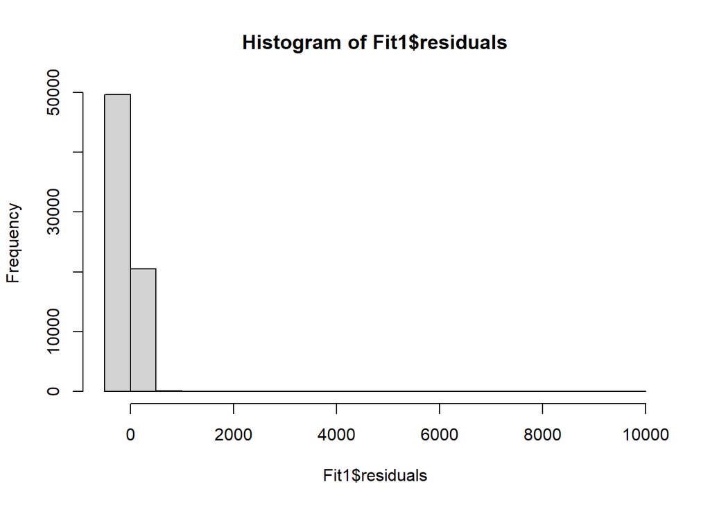

```r
hist(Fit1$residuals)
```

#create Q-Q plot for residuals

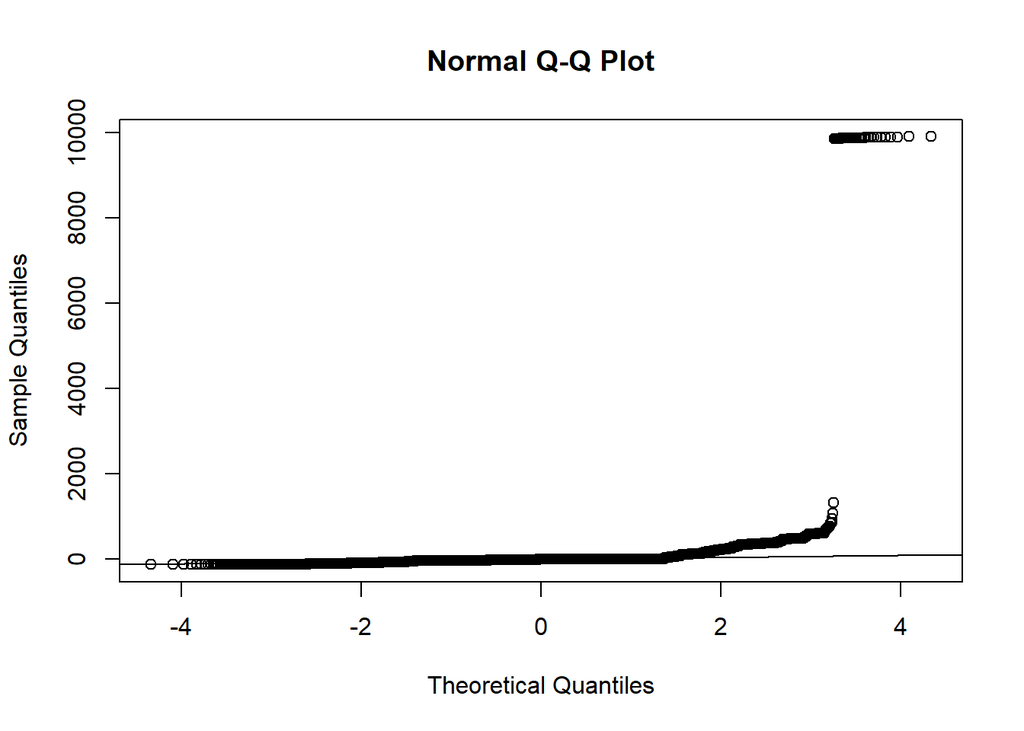

```r
qqnorm(Fit1$residuals)
qqline(Fit1$residuals)
```

## Adding Interaction term

```r
Fit2<-svyglm(pad630~sex+Edu_c+sex*Edu_c, design=SDes, na.action = na.omit)
summary(Fit2)
```

```
##
## Call:
## svyglm(formula = pad630 ~ sex + Edu_c + sex * Edu_c, design = SDes,
##     na.action = na.omit)
##
## Survey design:
## svydesign(id = ~sdmvpsu, weights = ~wtmec2yr, strata = ~sdmvstra,
##     nest = TRUE, survey.lonely.psu = "adjust", data = DF)
##
## Coefficients:
##                         Estimate Std. Error t value Pr(>|t|)
## (Intercept)              159.154      7.848  20.281  < 2e-16 ***
## sex                      -15.778      5.574  -2.831  0.00558 **
## Edu_cHigh Education      -16.467     12.306  -1.338  0.18377
## Edu_cDo not know         -50.867      9.068  -5.609 1.69e-07 ***
## sex:Edu_cHigh Education    1.094      7.331   0.149  0.88166
## sex:Edu_cDo not know      11.609      6.129   1.894  0.06099 .
## ---
## Signif. codes:  0 '***' 0.001 '**' 0.01 '*' 0.05 '.' 0.1 ' ' 1
##
## (Dispersion parameter for gaussian family taken to be 58434.87)
##
## Number of Fisher Scoring iterations: 2
```

## Some Health related variables for Analysis

```r
freq(DF$dpq010)
```

```
## Frequencies
## DF$dpq010
## Label: Little interest in doing things
## Type: Numeric
##
##                Freq   % Valid   % Valid Cum.   % Total   % Total Cum.
## ----------- ------- --------- -------------- --------- --------------
##           0   27342    38.954         38.954    38.954         38.954
##           1    5951     8.478         47.433     8.478         47.433
##           2    1718     2.448         49.880     2.448         49.880
##           3    1388     1.977         51.858     1.977         51.858
##           7      15     0.021         51.879     0.021         51.879
##           9      57     0.081         51.960     0.081         51.960
##          99   33719    48.040        100.000    48.040        100.000
##        <NA>       0                              0.000        100.000
##       Total   70190   100.000        100.000   100.000        100.000
```

##Smoking Intensity (SMQ040) Categories: Non-smoker, Occasionally, Regularly #(specific definitions may vary by cycle).

```r
freq(DF$smq040)
```

```
## Frequencies
## DF$smq040
## Label: Do you now smoke cigarettes
## Type: Numeric
##
##                Freq    % Valid   % Valid Cum.    % Total   % Total Cum.
## ----------- ------- ---------- -------------- ---------- --------------
##           1    6659     9.4871         9.4871     9.4871         9.4871
##           2    1556     2.2168        11.7039     2.2168        11.7039
##           3    9527    13.5732        25.2771    13.5732        25.2771
##           7       3     0.0043        25.2814     0.0043        25.2814
##          99   52445    74.7186       100.0000    74.7186       100.0000
##        <NA>       0                               0.0000       100.0000
##       Total   70190   100.0000       100.0000   100.0000       100.0000
```

```r
freq(DF$dbq700)
```

```
## Frequencies
## DF$dbq700
## Label: How healthy is the diet
## Type: Numeric
##
##                Freq    % Valid   % Valid Cum.    % Total   % Total Cum.
## ----------- ------- ---------- -------------- ---------- --------------
##           1    1546     2.2026         2.2026     2.2026         2.2026
##           2    3759     5.3555         7.5581     5.3555         7.5581
##           3    7678    10.9389        18.4969    10.9389        18.4969
##           4    4751     6.7688        25.2657     6.7688        25.2657
##           5    1214     1.7296        26.9953     1.7296        26.9953
##           9       4     0.0057        27.0010     0.0057        27.0010
##          99   51238    72.9990       100.0000    72.9990       100.0000
##        <NA>       0                               0.0000       100.0000
##       Total   70190   100.0000       100.0000   100.0000       100.0000
```

## Constructing Composite End-points

#We construct an ordinal outcome variable with the following six classes ($J=6$) (no chronic condition, 1, 2, 3, 4, #or 5 of the following conditions present). #Diabetes: The doctor told you have diabetes (“diq010”)

```r
freq(DF$diq010)
```

```
## Frequencies
## DF$diq010
## Label: Doctor told you have diabetes
## Type: Numeric
##
##                Freq    % Valid   % Valid Cum.    % Total   % Total Cum.
## ----------- ------- ---------- -------------- ---------- --------------
##           1    5231     7.4526         7.4526     7.4526         7.4526
##           2   60942    86.8243        94.2770    86.8243        94.2770
##           3     984     1.4019        95.6789     1.4019        95.6789
##           7       3     0.0043        95.6831     0.0043        95.6831
##           9      41     0.0584        95.7416     0.0584        95.7416
##          99    2989     4.2584       100.0000     4.2584       100.0000
##        <NA>       0                               0.0000       100.0000
##       Total   70190   100.0000       100.0000   100.0000       100.0000
```

#High blood pressure: Ever told you had high blood pressure (bpq020),

```r
freq(DF$bpq020)
```

```
## Frequencies
## DF$bpq020
## Label: Ever told you had high blood pressure
## Type: Numeric
##
##                Freq   % Valid   % Valid Cum.   % Total   % Total Cum.
## ----------- ------- --------- -------------- --------- --------------
##           1   14420    20.544         20.544    20.544         20.544
##           2   30215    43.047         63.592    43.047         63.592
##           9      65     0.093         63.684     0.093         63.684
##          99   25490    36.316        100.000    36.316        100.000
##        <NA>       0                              0.000        100.000
##       Total   70190   100.000        100.000   100.000        100.000
```

#Congestive heart failure: Ever told had congestive heart failure (mcq160b),\

```r
freq(DF$mcq160b)
```

```
## Frequencies
## DF$mcq160b
## Label: Ever told had congestive heart failure
## Type: Numeric
##
##                Freq   % Valid   % Valid Cum.   % Total   % Total Cum.
## ----------- ------- --------- -------------- --------- --------------
##           1    1168      1.66           1.66      1.66           1.66
##           2   32924     46.91          48.57     46.91          48.57
##           9      97      0.14          48.71      0.14          48.71
##          99   36001     51.29         100.00     51.29         100.00
##        <NA>       0                               0.00         100.00
##       Total   70190    100.00         100.00    100.00         100.00
```

#Coronary heart disease: Ever told you had coronary heart disease (mcq160c)\

```r
freq(DF$mcq160c)
```

```
## Frequencies
## DF$mcq160c
## Label: Ever told you had coronary heart disease
## Type: Numeric
##
##                Freq   % Valid   % Valid Cum.   % Total   % Total Cum.
## ----------- ------- --------- -------------- --------- --------------
##           1    1448      2.06           2.06      2.06           2.06
##           2   32598     46.44          48.51     46.44          48.51
##           9     143      0.20          48.71      0.20          48.71
##          99   36001     51.29         100.00     51.29         100.00
##        <NA>       0                               0.00         100.00
##       Total   70190    100.00         100.00    100.00         100.00
```

#Heart attack: Ever told you had a heart attack (mcq160e);\

```r
freq(DF$mcq160e)
```

```
## Frequencies
## DF$mcq160e
## Label: Ever told you had heart attack
## Type: Numeric
##
##                Freq   % Valid   % Valid Cum.   % Total   % Total Cum.
## ----------- ------- --------- -------------- --------- --------------
##           1    1509     2.150          2.150     2.150          2.150
##           2   32622    46.477         48.627    46.477         48.627
##           9      58     0.083         48.709     0.083         48.709
##          99   36001    51.291        100.000    51.291        100.000
##        <NA>       0                              0.000        100.000
##       Total   70190   100.000        100.000   100.000        100.000
```

### The Composite Outcome

```r
DF$chronic_count <- rowSums(DF[, c("diq010", "bpq020", "mcq160b", "mcq160c", "mcq160e")] == 1, na.rm = TRUE)
freq(DF$chronic_count)
```

```
## Frequencies
## DF$chronic_count
## Type: Numeric
##
##                Freq   % Valid   % Valid Cum.   % Total   % Total Cum.
## ----------- ------- --------- -------------- --------- --------------
##           0   53611     76.38          76.38     76.38          76.38
##           1   11396     16.24          92.62     16.24          92.62
##           2    3796      5.41          98.02      5.41          98.02
##           3     879      1.25          99.28      1.25          99.28
##           4     389      0.55          99.83      0.55          99.83
##           5     119      0.17         100.00      0.17         100.00
##        <NA>       0                               0.00         100.00
##       Total   70190    100.00         100.00    100.00         100.00
```

##Creating a binary variable

```r
DF$chronic_binary<-ifelse(DF$chronic_count==0,0,1)
freq(DF$chronic_binary)
```

```
## Frequencies
## DF$chronic_binary
## Type: Numeric
##
##                Freq   % Valid   % Valid Cum.   % Total   % Total Cum.
## ----------- ------- --------- -------------- --------- --------------
##           0   53611     76.38          76.38     76.38          76.38
##           1   16579     23.62         100.00     23.62         100.00
##        <NA>       0                               0.00         100.00
##       Total   70190    100.00         100.00    100.00         100.00
```

## Odds Ratio

##Association between Income and Chronic Condition # Using GLM method

```r
fit= glm(chronic_binary~ Income_c, data=DF, family=binomial(link="logit"))
exp(cbind(coef(fit), confint(fit)))
```

```
##                                   2.5 %    97.5 %
## (Intercept)         0.3500176 0.3416868 0.3585182
## Income_cHigh Income 0.8063099 0.7746495 0.8391898
## Income_cDo not know 0.7306717 0.6963328 0.7665254
```

```r
fit= glm(chronic_binary~ Income_c, data=DF, family=binomial(link="logit"))
exp(cbind(coef(fit), confint(fit)))
```

```
##                                   2.5 %    97.5 %
## (Intercept)         0.3500176 0.3416868 0.3585182
## Income_cHigh Income 0.8063099 0.7746495 0.8391898
## Income_cDo not know 0.7306717 0.6963328 0.7665254
```

```r
library(epitools)
table(DF$Income_c,DF$chronic_binary)
```

```
##
##                   0     1
##   Low Income  25633  8972
##   High Income 17061  4815
##   Do not know 10917  2792
```

```r
Income_name<-c("low income", "High income", "Unknown")
Chronic_name<-c("No Chronic", "Have Chronic")
Data1 <- matrix(c(25633, 8972, 17061, 4815, 10917,  2792), nrow=3, ncol=2, byrow=TRUE)
dimnames(Data1) <- list('Program'=Income_name, 'Outcome'=Chronic_name)
OR<-oddsratio(Data1)
```

##Final Result

```r
cbind(OR$measure, OR$p.value)
```

```
##              estimate     lower     upper midp.exact fisher.exact   chi.square
## low income  1.0000000        NA        NA         NA           NA           NA
## High income 0.8063323 0.7746411 0.8391860          0 2.933809e-26 4.788464e-26
## Unknown     0.7306989 0.6963586 0.7665527          0 1.349500e-38 9.966386e-38
```

## Survey Weighted Odds ratio

Recall data

```r
SDes <- svydesign(id=~sdmvpsu, weights=~wtmec2yr,strata=~sdmvstra, nest=TRUE, survey.lonely.psu = "adjust", data=DF)
SDes
```

```
## Stratified 1 - level Cluster Sampling design (with replacement)
## With (214) clusters.
## svydesign(id = ~sdmvpsu, weights = ~wtmec2yr, strata = ~sdmvstra,
##     nest = TRUE, survey.lonely.psu = "adjust", data = DF)
```

## Using GLM method

```r
attach(DF)
Fit1<-svyglm(chronic_binary~Income_c, family=quasibinomial, design=SDes, na.action = na.omit)
summary(Fit1)
```

```
##
## Call:
## svyglm(formula = chronic_binary ~ Income_c, design = SDes, family = quasibinomial,
##     na.action = na.omit)
##
## Survey design:
## svydesign(id = ~sdmvpsu, weights = ~wtmec2yr, strata = ~sdmvstra,
##     nest = TRUE, survey.lonely.psu = "adjust", data = DF)
##
## Coefficients:
##                     Estimate Std. Error t value Pr(>|t|)
## (Intercept)         -0.89928    0.02545 -35.335  < 2e-16 ***
## Income_cHigh Income -0.21725    0.03424  -6.345 5.46e-09 ***
## Income_cDo not know -0.17511    0.05174  -3.384 0.000999 ***
## ---
## Signif. codes:  0 '***' 0.001 '**' 0.01 '*' 0.05 '.' 0.1 ' ' 1
##
## (Dispersion parameter for quasibinomial family taken to be 1.000015)
##
## Number of Fisher Scoring iterations: 4
```

```r
exp(cbind(coef(Fit1), confint(Fit1)))
```

```
##                                   2.5 %    97.5 %
## (Intercept)         0.4068632 0.3868455 0.4279167
## Income_cHigh Income 0.8047252 0.7519168 0.8612424
## Income_cDo not know 0.8393662 0.7575346 0.9300375
```

```r
D1<-data.frame(exp(cbind(coef(Fit1), confint(Fit1))), coef(summary(Fit1))[,'Pr(>|t|)'])
names(D1)<-c("OR", "95%LCL", "95%UCL", "P value")
D1
```

```
##                            OR    95%LCL    95%UCL      P value
## (Intercept)         0.4068632 0.3868455 0.4279167 8.074436e-61
## Income_cHigh Income 0.8047252 0.7519168 0.8612424 5.458422e-09
## Income_cDo not know 0.8393662 0.7575346 0.9300375 9.990273e-04
```

# Survey Weighted and Adjusted for Covariates Odds ratio

```r
Fit2<-svyglm(chronic_binary~Income_c+age+sex, family=quasibinomial, design=SDes, na.action = na.omit)
summary(Fit2)
```

```
##
## Call:
## svyglm(formula = chronic_binary ~ Income_c + age + sex, design = SDes,
##     family = quasibinomial, na.action = na.omit)
##
## Survey design:
## svydesign(id = ~sdmvpsu, weights = ~wtmec2yr, strata = ~sdmvstra,
##     nest = TRUE, survey.lonely.psu = "adjust", data = DF)
##
## Coefficients:
##                       Estimate Std. Error t value Pr(>|t|)
## (Intercept)         -3.7987024  0.0578588 -65.655  < 2e-16 ***
## Income_cHigh Income -0.2881896  0.0393440  -7.325 5.09e-11 ***
## Income_cDo not know -0.1943120  0.0706516  -2.750  0.00701 **
## age                  0.0723439  0.0008841  81.825  < 2e-16 ***
## sex                 -0.1753355  0.0312572  -5.609 1.66e-07 ***
## ---
## Signif. codes:  0 '***' 0.001 '**' 0.01 '*' 0.05 '.' 0.1 ' ' 1
##
## (Dispersion parameter for quasibinomial family taken to be 0.8578586)
##
## Number of Fisher Scoring iterations: 5
```

```r
exp(cbind(coef(Fit2), confint(Fit2)))
```

```
##                                     2.5 %     97.5 %
## (Intercept)         0.02239982 0.01997197 0.02512281
## Income_cHigh Income 0.74961945 0.69336314 0.81044013
## Income_cDo not know 0.82340095 0.71576665 0.94722089
## age                 1.07502503 1.07314208 1.07691129
## sex                 0.83917546 0.78874461 0.89283076
```

```r
D2<-data.frame(exp(cbind(coef(Fit2), confint(Fit2))), coef(summary(Fit2))[,'Pr(>|t|)'])
names(D2)<-c("OR", "95%LCL", "95%UCL", "P value")
D2
```

```
##                             OR     95%LCL     95%UCL      P value
## (Intercept)         0.02239982 0.01997197 0.02512281 4.428211e-87
## Income_cHigh Income 0.74961945 0.69336314 0.81044013 5.092239e-11
## Income_cDo not know 0.82340095 0.71576665 0.94722089 7.013397e-03
## age                 1.07502503 1.07314208 1.07691129 6.287487e-97
## sex                 0.83917546 0.78874461 0.89283076 1.659361e-07
```

# Survey Weighted and Adjusted for Covariates with interactions Odds ratio

```r
Fit3<-svyglm(chronic_binary~Income_c+age+sex+age*Income+sex*Income, family=quasibinomial, design=SDes, na.action = na.omit)
summary(Fit3)
```

```
##
## Call:
## svyglm(formula = chronic_binary ~ Income_c + age + sex + age *
##     Income + sex * Income, design = SDes, family = quasibinomial,
##     na.action = na.omit)
##
## Survey design:
## svydesign(id = ~sdmvpsu, weights = ~wtmec2yr, strata = ~sdmvstra,
##     nest = TRUE, survey.lonely.psu = "adjust", data = DF)
##
## Coefficients:
##                       Estimate Std. Error t value Pr(>|t|)
## (Intercept)         -3.646e+00  6.829e-02 -53.395  < 2e-16 ***
## Income_cHigh Income -1.052e-01  5.293e-02  -1.988   0.0495 *
## Income_cDo not know  1.947e+00  4.294e-01   4.534 1.58e-05 ***
## age                  7.312e-02  1.001e-03  73.053  < 2e-16 ***
## sex                 -2.179e-01  3.810e-02  -5.719 1.08e-07 ***
## Income              -2.429e-02  5.211e-03  -4.661 9.56e-06 ***
## age:Income          -3.282e-05  2.264e-05  -1.449   0.1503
## sex:Income           1.657e-03  9.708e-04   1.706   0.0910 .
## ---
## Signif. codes:  0 '***' 0.001 '**' 0.01 '*' 0.05 '.' 0.1 ' ' 1
##
## (Dispersion parameter for quasibinomial family taken to be 0.8573692)
##
## Number of Fisher Scoring iterations: 5
```

```r
exp(cbind(coef(Fit3), confint(Fit3)))
```

```
##                                     2.5 %      97.5 %
## (Intercept)         0.02608524 0.02278075  0.02986906
## Income_cHigh Income 0.90013958 0.81043529  0.99977293
## Income_cDo not know 7.00705212 2.98964374 16.42295330
## age                 1.07586354 1.07372962  1.07800169
## sex                 0.80420793 0.74566725  0.86734451
## Income              0.97600659 0.96597093  0.98614650
## age:Income          0.99996718 0.99992227  1.00001209
## sex:Income          1.00165788 0.99973090  1.00358858
```

```r
D3<-data.frame(exp(cbind(coef(Fit3), confint(Fit3))), coef(summary(Fit3))[,'Pr(>|t|)'])
names(D3)<-c("OR", "95%LCL", "95%UCL", "P value")
D3
```

```
##                             OR     95%LCL      95%UCL      P value
## (Intercept)         0.02608524 0.02278075  0.02986906 2.284489e-76
## Income_cHigh Income 0.90013958 0.81043529  0.99977293 4.951566e-02
## Income_cDo not know 7.00705212 2.98964374 16.42295330 1.582203e-05
## age                 1.07586354 1.07372962  1.07800169 6.742303e-90
## sex                 0.80420793 0.74566725  0.86734451 1.077368e-07
## Income              0.97600659 0.96597093  0.98614650 9.557462e-06
## age:Income          0.99996718 0.99992227  1.00001209 1.502951e-01
## sex:Income          1.00165788 0.99973090  1.00358858 9.099978e-02
```

## Subgroup Analysis

```r
subset1 <- subset(SDes, age > 20)
Fit4<-svyglm(chronic_binary~Income_c, family=quasibinomial, design=subset1, na.action = na.omit)
summary(Fit4)
```

```
##
## Call:
## svyglm(formula = chronic_binary ~ Income_c, design = subset1,
##     family = quasibinomial, na.action = na.omit)
##
## Survey design:
## subset(SDes, age > 20)
##
## Coefficients:
##                     Estimate Std. Error t value Pr(>|t|)
## (Intercept)         -0.41027    0.02785 -14.731  < 2e-16 ***
## Income_cHigh Income -0.26627    0.03610  -7.377 3.65e-11 ***
## Income_cDo not know -0.20190    0.05223  -3.865 0.000191 ***
## ---
## Signif. codes:  0 '***' 0.001 '**' 0.01 '*' 0.05 '.' 0.1 ' ' 1
##
## (Dispersion parameter for quasibinomial family taken to be 1.000027)
##
## Number of Fisher Scoring iterations: 4
```

```r
D4<-data.frame(exp(cbind(coef(Fit4), confint(Fit4))), coef(summary(Fit4))[,'Pr(>|t|)'])
names(D4)<-c("OR", "95%LCL", "95%UCL", "P value")
D4
```

```
##                            OR    95%LCL    95%UCL      P value
## (Intercept)         0.6634700 0.6278312 0.7011318 1.696942e-27
## Income_cHigh Income 0.7662353 0.7133229 0.8230726 3.645371e-11
## Income_cDo not know 0.8171779 0.7367987 0.9063258 1.905374e-04
```

## Model fit Criteria for Logistic regression

```r
psrsq(Fit1, method = c("Cox-Snell"))
```

```
## [1] 0.002042065
```

```r
psrsq(Fit2, method = c("Cox-Snell"))
```

```
## [1] 0.2801597
```

```r
psrsq(Fit3, method = c("Cox-Snell"))
```

```
## [1] 0.2808208
```

## ROC Analysis

##Assess test performance: Measures ability to distinguish disease vs. non-disease. ##AUC provides a single performance metric. ##Compare models: Identifies the best diagnostic or predictive model. ##Select thresholds: Balances sensitivity and specificity for clinical needs. ##Visualize results: Graphically represents model performance. ##Guide decisions: Supports better diagnostic and treatment strategies. ##Highlight trade-offs: Shows sensitivity vs. specificity balance. ##Handle imbalances: Works well with uneven disease prevalence.

```r
library(pROC)
library(ROCR)
```

# Calculate ROC curve for unweighted data

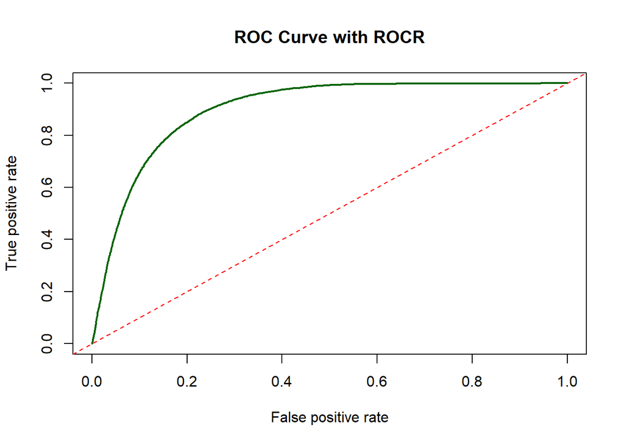

```r
fit= glm(chronic_binary~ Income_c+age+sex, data=DF, family=binomial(link="logit"))
# Create prediction object
pred <- prediction(fit$fitted.values, chronic_binary)
# Calculate performance (True Positive Rate and False Positive Rate)
perf <- performance(pred, "tpr", "fpr")

# Plot the ROC curve
plot(perf, col = "darkgreen", lwd = 2, main = "ROC Curve with ROCR")

# Add a diagonal reference line
abline(a = 0, b = 1, col = "red", lty = 2)
```

## Method 2 with cutpoint

```r
library(pROC)
g <- roc(chronic_binary ~ fit$fitted.values, data = DF, )
g
```

```
##
## Call:
## roc.formula(formula = chronic_binary ~ fit$fitted.values, data = DF,     )
##
## Data: fit$fitted.values in 53611 controls (chronic_binary 0) < 16579 cases (chronic_binary 1).
## Area under the curve: 0.8999
```

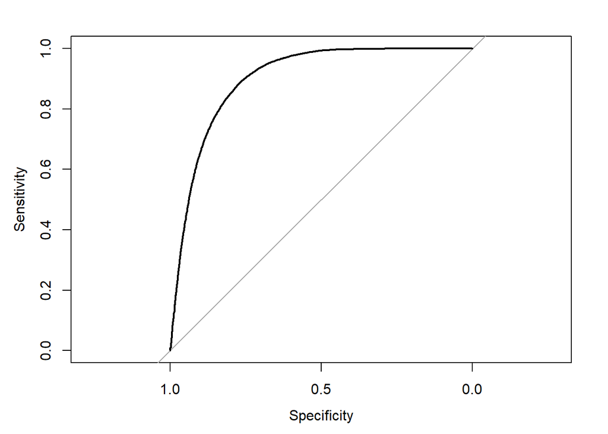

```r
plot(g)
```

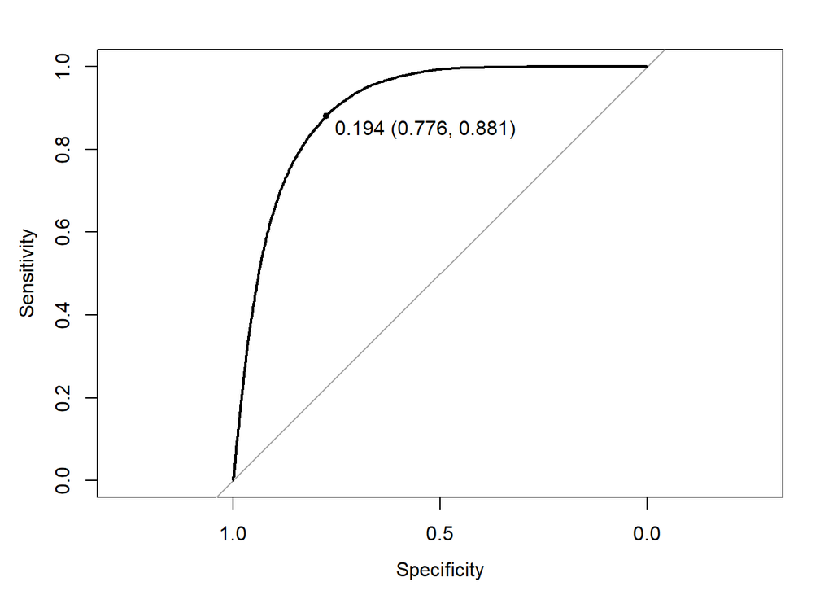

```r
plot(g, print.thres=TRUE)
```